# Introduction

Over three decades ago, research showed that Muslim Americans had well-developed political ideologies but lacked opportunities to influence American politics. Political participation data often reflected common sentiments among Muslims of disengagement with the political sphere (Hougland and Christenson 1983). Despite comprising a wealthy and well-educated segment of the population and theories to show correlative effects between affluence and political engagement, Muslim Americans were simply absent from this significant marker of integration. But everything changed post 9-11 as anxiety, fear, and defensiveness proved to be catalysts for political mobilization (Ayers and Hofstetter 2008). In their 2004 study, Ayers and Hofstetter show that Muslim anxiety and sensitivity post 9-11 accounted for a near 20% increase in voting from 1995. Muslim Americans were also more likely to be involved in a political party, demonstrate in a protest, or donate to a political campaign as a result, making them politically engaged on multiple levels.

I am interested in seeing the changes in Muslim American political participation since this research was produced. 9-11 created a heightened sense of awareness of Islamic extremism domestically. But since then, Muslim Americans have had to face external threats as well. The growth of ISIS and other Muslim militant groups (Hamas, Hezbollah, Al Shabab, etc.) and the acts of terror that pledge allegiance to them have induced new fears in the global West. While militant groups engage in destructive wars in some Middle Eastern and African countries and threaten destabilization in others, policies combating potential terrorism directly target Muslims abroad and have increasingly taken shape throughout countries with large Muslim minorities. If 9-11, and the perceived threats to Muslim Americans generated as a result, was a significant indicator in explaining increased political participation, what role have recent events and global trends played in their political engagement? Are rates of participation in line with previous research that linked increased anxiety with increased political participation or have new events depoliticized Muslim Americans and led them to pursue paths of consulation and solidarity within their community over fruitless political endeavors?

By using the Pew Research Center’s 2017 survey of U.S. Muslims, I will assess new data on Muslim American political involvement to posit changes over time. I am interested in seeing the correlation between Islamic affiliation and political participation broadly, but to understand the degree of interaction, I will control for two factors: degree of religiosity and immigrant generation level. By providing variation on Muslim American minorities, these two variables will provide us with added knowledge on who within the community is more likely to be politically motivated. While degree of religiosity can show us whether religious devotion is likely to induce political involvement, looking at immigrant generation levels can tell us whether those who are more likely integrated into American society will feel more comfortable participating in its politics. Perhaps atypically, I believe there to be a contrasting effect between these variables. I hypothesize the relationship between relgiosity and political participation to decrease as one becomes less religious but to increase among Muslim Americans of higher generations.

# Data and Methods

My data comes from the Pew Research Center. The data is comprised of results from a 2017 survey, conducted over fourteen weeks in 2016, on U.S. Muslims’ feelings towards their place in society. Pew’s data is the result of 1,001 phone interviews with Muslim Americans 18 or older. In identifying target respondents, researchers relied on existing data from the U.S. Census Bureau and the American Community Survey on the Muslim American community to create a sampling plan that they believe speaks to the larger diaspora of Muslim Americans nationally. This means the number of initial screening interviews was very high- at about 40,000 phone numbers- but allowed enough room to maneuver to screen-out respondents in achieving a confident sample.

Respondents were weighted and ranked which means the design took into account areas with large Muslim congregations, respondent’s birth regions, multi-adult households, and adults with both landline and cellphone numbers. They then created separate frames for each, weighted phone numbers that fit into those categories and divided them between stratums ranging from, for example, “Very high Muslim density” to “lowest Muslim density.” In doing this, the design could both account for duplicates and yield a high probability sample since technically each adult in the U.S. had a probability of being included in the study.

The goal of the survey was to provide a broad description of Muslim American characteristics and attitudes and therefore drew on previous surveys of Muslim Americans from 2007 and 2011 to maintain this level of efficacy. They did, however, adjust the 2017 strategy to deal with increased concerns of government surveillance and accountability. To achieve this, interviews were conducted over the phone in English or the respondent’s native language if necessary. In first establishing rapport with the respondent, surveyers asked broad questions and included questions on multiple relgious backgrounds to make the respondent feel they were not being targeted based on their religious affiliations. The interview included more than one attempt to identify relgious affiliation should the respondent feel uncomfortable in revealing this information from the outset and included a $50 incentive should they complete the survey. Once the interview was under way, the surveyors followed the survey design in asking broad quesions ranging from citizenship status to perceptions on American society.

For my methods, I created a number of data frames in order to create my variables. For example, for voters, I only included the respondents who were eligible to vote and assigned missing values to those who were not. Therefore, my data does not include underage respondents or those who were not U.S. citizens. Immigrant generation information is comprised of data on the respondent’s birth region along with their mother and father’s birth regions. If the respondent had one native-born and one foreign-born parent, I sorted them into a separate “2.5 Generation” category that could account for any correlation between one foreign born parent and voting outcomes. I also controlled for respondent religious denomination and birth region. Since Pew data categorized respondents into regions rather than countries - in other words, the Middle East and North Africa (MENA) was one region- I felt that accounting for demonination could partially overcome the large subsections. Since Iran is a predominantly Shia country and Iranian immigrants tend to be more conservative than their Sunni counterparts, I was interested in seeing whether there would be correlative patterns between this distribution and voting behavior, specifically for those who voted for Clinton and Trump in the last election. Lastly, as third generation respondents were the second largest category of respondents, I wanted to see whether age could be a motivating factor for voting tendencies, for example, since generally people tend to vote more (or more conservatively) as they age.

# Results

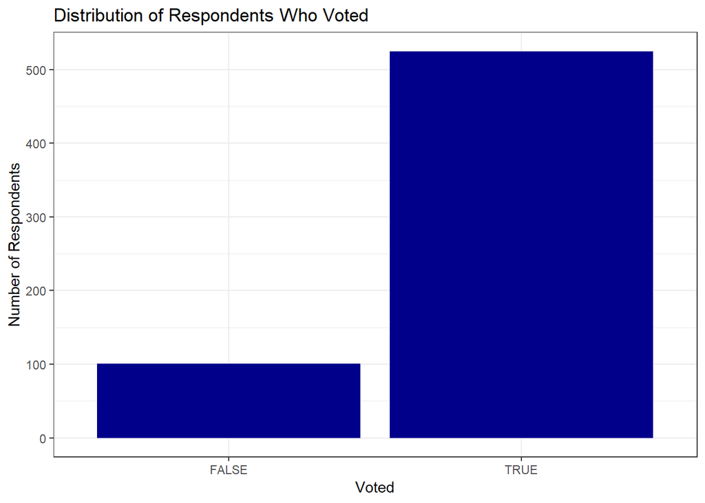

Distribution of Respondents Who Voted

```r
ggplot(analytical_data, aes(x=yesvote))+
  geom_bar(fill='darkblue')+
  labs(title= "Distribution of Respondents Who Voted",
       x="Voted", y="Number of Respondents")+
  theme_bw()
```

The focus of this study was on voting behavior among Muslim immigrants. According to the distribution above, on average, Muslims vote more than the status quo. Well over four-fifths of eligible voters voted in the last election.

Based off of this distribution, we see that most eligible voters voted for Clinton in the 2016 election. Although, there was also a substantial number of voters (101 in total) who, although eligible, did not vote. Lastly, around 63 of the respondents reported voting third party and only 39 voted for Trump.

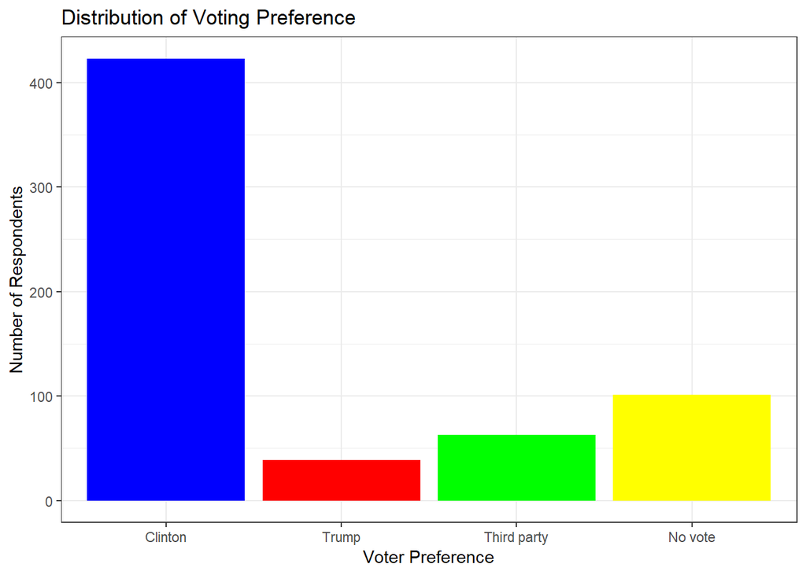

Distribution of Voting Preferences

```r
ggplot(analytical_data, aes(x=vote))+
  geom_bar(fill=c("#0000FF", "#FF0000", "#00FF00", "#FFFF00"))+
  labs(title= "Distribution of Voting Preference",
       x="Voter Preference", y="Number of Respondents")+ theme_bw()
```

In order to see the distribution of the respondents across my key variables, I have also included below descriptive univariate graphs illustrating respondent distribution on immigrant generation level and degree of religiosity. Clearly, most of the respondents were first generation immigrants, comprising over half of the sample. Distribution of respondents based on religious importance was equally disporportionate. Respondents are distributed into categories based on answers they provided to the question, “How important is religion in your every day life?” 421 Respondents perceived relgion as a fundamental aspect of their lives while only 20 assigned it of little importance.

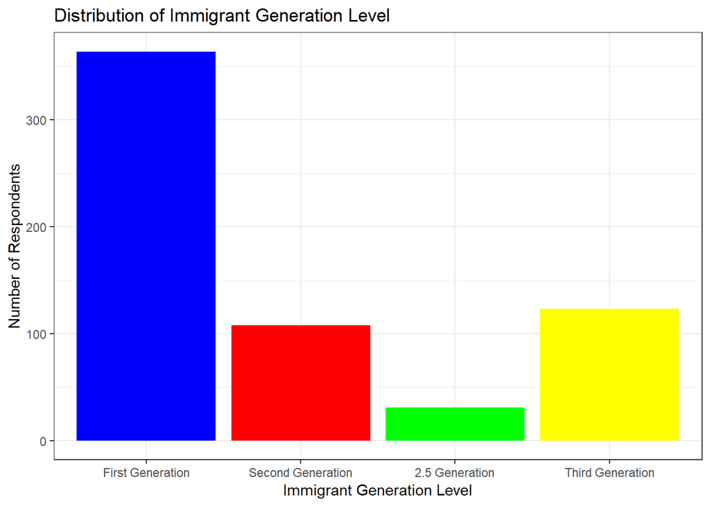

Distribution of generation

```r
ggplot(analytical_data, aes(x=generation))+
  geom_bar(fill=c("#0000FF", "#FF0000", "#00FF00", "#FFFF00"))+
  labs(title= "Distribution of Immigrant Generation Level",
       x="Immigrant Generation Level", y="Number of Respondents")+
  theme_bw()
```

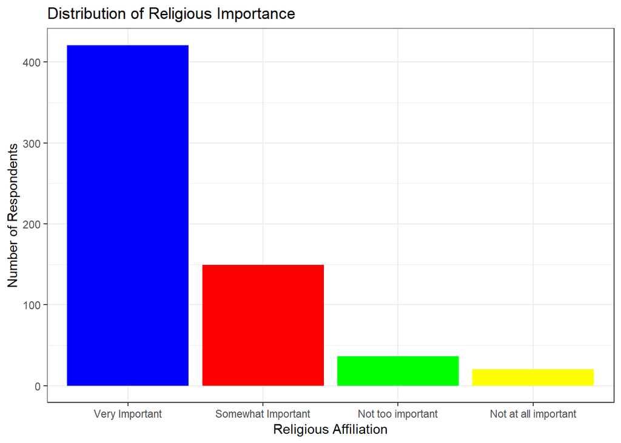

Distribution of religion

```r
ggplot(analytical_data, aes(x=religion))+
  geom_bar(fill=c("#0000FF", "#FF0000", "#00FF00", "#FFFF00"))+
  labs(title= "Distribution of Religious Importance",
       x="Religious Affiliation", y="Number of Respondents")+
  theme_bw()
```

```r
reli_yes_vote <- table(analytical_data$religion, analytical_data$yesvote)
reli_yes_vote_pct <- (reli_yes_vote / rowSums(reli_yes_vote)*100)
reli_yes_vote_pct
```

```
##
##                            FALSE      TRUE
##   Very Important       18.289786 81.710214
##   Somewhat Important   12.751678 87.248322
##   Not too important     5.555556 94.444444
##   Not at all important 15.000000 85.000000
```

```r
gen_voted <- table(analytical_data$generation, analytical_data$yesvote)
gen_voted_pct <- gen_voted / rowSums(gen_voted)*100
gen_voted_pct
```

```
##
##                         FALSE      TRUE
##   First Generation  16.758242 83.241758
##   Second Generation 13.888889 86.111111
##   2.5 Generation     9.677419 90.322581
##   Third Generation  17.886179 82.113821
```

As we further meet at the intersection between religiosity and voting patterns, we see variation among religious levels and candidate/party choice. Once again, there are correlations between those who find religion very important and those who do not as both categories include large percentages of respondents who did not partake in the election.

```r
reli_voted <- table(analytical_data$religion, analytical_data$vote)
reli_voted_pct <- reli_voted /rowSums(reli_voted)*100
reli_voted_pct
```

```
##
##                          Clinton     Trump Third party   No vote
##   Very Important       66.983373  5.225653    9.501188 18.289786
##   Somewhat Important   67.114094  8.724832   11.409396 12.751678
##   Not too important    75.000000  5.555556   13.888889  5.555556
##   Not at all important 70.000000 10.000000    5.000000 15.000000
```

For the next case, I have included information on denomination. Although I hypothesized that a Sunni/Shia differentiation would lead to positive conservative voting behavior for Shiites and negative correlation for Sunnis, we see the reverse. There is a slightly higher percentage of Shiites who voted for Clinton over Trump than Sunnis. Surprisingly, those who did not vote frequented non-denominational or ‘other’ categories.

```r
denom_voted <- table(analytical_data$denom, analytical_data$vote)
denom_voted_pct <- denom_voted / rowSums(denom_voted)*100
denom_voted_pct
```

```
##
##                        Clinton     Trump Third party   No vote
##   Shia               73.255814  6.976744    8.139535 11.627907
##   Sunni              69.926650  4.156479   10.513447 15.403423
##   Other              55.172414 10.344828   10.344828 24.137931
##   Non-Denominational 58.666667  8.000000    9.333333 24.000000
```

In the next section I have included sets of bivariate plots that better illustrate findings across immigrant generation and religiosity levels. In the first instance, we can compare voting behavior by generation. Although there is some variation for second generation immigrants in that we see an increase in third party voting, this graph shows significant voting patterns for Clinton across all generation levels, and large voting abstinence for the first and third generation immigrants.

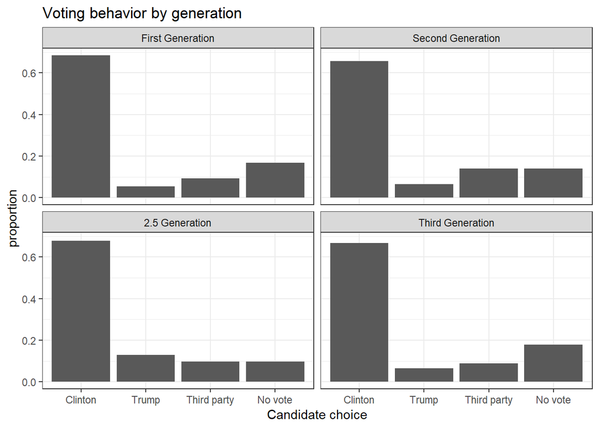

Voting behavior by generation

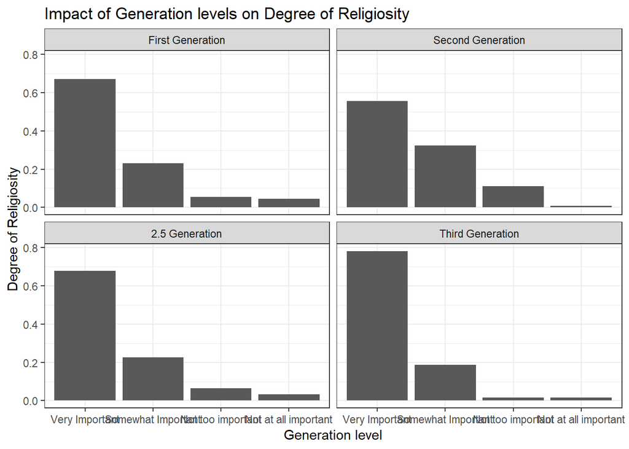

Impact of Generation levels on Degree of Religiosity

In the second instance below, we can see the distribution of respondents of varying religious significance and their voting behaviors. Once again surprising, those who found religion not to be at all important voted the most for Trump. I initially hypothesized that as one becomes less religious, their level of political participation would decline. Although we do see a significant number of respondents who did not vote, this number does not trump the respondents who did not vote and found religion to be very important, showing that an increase in religious behavior is not likely to induce voting anymore than a decrease in such belief.

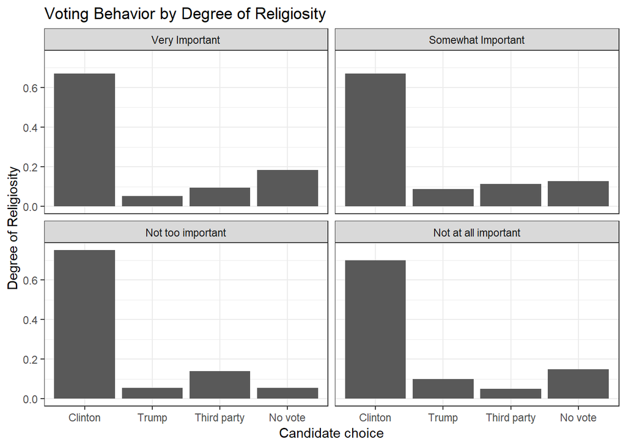

Voting Behavior by Degree of Religiosity

```r
analytical_data$relig_score <-  5-as.numeric(analytical_data$religion)
model <- lm(relig_score~generation, data=analytical_data)
texreg(model,
        caption = "Predicting religiosity score by generation",
        caption.above = TRUE,
        doctype = FALSE)
```

[output not shown]

```r
model.lpm <- glm(vote!="No vote"~generation + I(religion=="Very Important")+factor(age), data= analytical_data, family=binomial)
texreg(model.lpm,
        caption = "Predicting Voting by Age Bracket",
        caption.above = TRUE,
        doctype = FALSE)
```

[output not shown]

# References

Ayers, J., & Hofstetter, C. (2008). American Muslim Political Participation Following 9/11: Religious Belief, Political Resources, Social Structures, and Political Awareness. Politics and Religion, 1(1), 3-26. doi:10.1017/S1755048308000023

Hougland, James G., and James A. Christenson. 1983. “Religion and Politics: TheRelationship of Religious Participation to Political Efficacy and Involvement.”Sociology and Social Research67:405–420.